# Part I - Prosper Loan Data

## Introduction

> The Prosper Loan Dataset consists of 113,937 loan records, each with 81 variables. In our analysis, we aim to examine key metrics and identify the variables that influence them.

## Preliminary Wrangling

```python
# importing important packages
import numpy as np
import pandas as pd
import matplotlib.pyplot as plt
import seaborn as sns
import scipy
import warnings
import scipy.stats as stats

warnings.filterwarnings('ignore')
pd.set_option('display.max_columns', None)
pd.set_option('display.max_rows', None)
```

```python
# Reading in the data and creating a copy
og_data = pd.read_csv('prosperLoanData.csv')
data = og_data.copy()
```

```python
data.head(5)
```

|  | ListingKey | ListingNumber | ListingCreationDate | CreditGrade | Term | LoanStatus | ClosedDate | BorrowerAPR | BorrowerRate | LenderYield | EstimatedEffectiveYield | EstimatedLoss | EstimatedReturn | ProsperRating (numeric) | ProsperRating (Alpha) | ProsperScore | ListingCategory (numeric) | BorrowerState | Occupation | EmploymentStatus | EmploymentStatusDuration | IsBorrowerHomeowner | CurrentlyInGroup | GroupKey | DateCreditPulled | CreditScoreRangeLower | CreditScoreRangeUpper | FirstRecordedCreditLine | CurrentCreditLines | … |
| --- | --- | --- | --- | --- | --- | --- | --- | --- | --- | --- | --- | --- | --- | --- | --- | --- | --- | --- | --- | --- | --- | --- | --- | --- | --- | --- | --- | --- | --- | --- |
| 0 | 1021339766868145413AB3B | 193129 | 2007-08-26 19:09:29.263000000 | C | 36 | Completed | 2009-08-14 00:00:00 | 0.16516 | 0.1580 | 0.1380 | NaN | NaN | NaN | NaN | NaN | NaN | 0 | CO | Other | Self-employed | 2.0 | True | True | NaN | 2007-08-26 18:41:46.780000000 | 640.0 | 659.0 | 2001-10-11 00:00:00 | 5.0 | … |
| 1 | 10273602499503308B223C1 | 1209647 | 2014-02-27 08:28:07.900000000 | NaN | 36 | Current | NaN | 0.12016 | 0.0920 | 0.0820 | 0.07960 | 0.0249 | 0.05470 | 6.0 | A | 7.0 | 2 | CO | Professional | Employed | 44.0 | False | False | NaN | 2014-02-27 08:28:14 | 680.0 | 699.0 | 1996-03-18 00:00:00 | 14.0 | … |
| 2 | 0EE9337825851032864889A | 81716 | 2007-01-05 15:00:47.090000000 | HR | 36 | Completed | 2009-12-17 00:00:00 | 0.28269 | 0.2750 | 0.2400 | NaN | NaN | NaN | NaN | NaN | NaN | 0 | GA | Other | Not available | NaN | False | True | 783C3371218786870A73D20 | 2007-01-02 14:09:10.060000000 | 480.0 | 499.0 | 2002-07-27 00:00:00 | NaN | … |
| 3 | 0EF5356002482715299901A | 658116 | 2012-10-22 11:02:35.010000000 | NaN | 36 | Current | NaN | 0.12528 | 0.0974 | 0.0874 | 0.08490 | 0.0249 | 0.06000 | 6.0 | A | 9.0 | 16 | GA | Skilled Labor | Employed | 113.0 | True | False | NaN | 2012-10-22 11:02:32 | 800.0 | 819.0 | 1983-02-28 00:00:00 | 5.0 | … |
| 4 | 0F023589499656230C5E3E2 | 909464 | 2013-09-14 18:38:39.097000000 | NaN | 36 | Current | NaN | 0.24614 | 0.2085 | 0.1985 | 0.18316 | 0.0925 | 0.09066 | 3.0 | D | 4.0 | 2 | MN | Executive | Employed | 44.0 | True | False | NaN | 2013-09-14 18:38:44 | 680.0 | 699.0 | 2004-02-20 00:00:00 | 19.0 | … |

```python
# Quick overview of our data
print(data.shape, '\n')
print(data.dtypes, '\n')
print(data.columns, '\n')
print(data.isnull().sum())
```

```
(113937, 81)

ListingKey                              object
ListingNumber                            int64
ListingCreationDate                     object
CreditGrade                             object
Term                                     int64
LoanStatus                              object
ClosedDate                              object
BorrowerAPR                            float64
BorrowerRate                           float64
LenderYield                            float64
EstimatedEffectiveYield                float64
EstimatedLoss                          float64
EstimatedReturn                        float64
ProsperRating (numeric)                float64
ProsperRating (Alpha)                   object
ProsperScore                           float64
ListingCategory (numeric)                int64
BorrowerState                           object
Occupation                              object
EmploymentStatus                        object
EmploymentStatusDuration               float64
IsBorrowerHomeowner                       bool
CurrentlyInGroup                          bool
GroupKey                                object
DateCreditPulled                        object
CreditScoreRangeLower                  float64
CreditScoreRangeUpper                  float64
FirstRecordedCreditLine                 object
CurrentCreditLines                     float64
OpenCreditLines                        float64
TotalCreditLinespast7years             float64
OpenRevolvingAccounts                    int64
OpenRevolvingMonthlyPayment            float64
InquiriesLast6Months                   float64
TotalInquiries                         float64
CurrentDelinquencies                   float64
AmountDelinquent                       float64
DelinquenciesLast7Years                float64
```

[output cut: 145 more lines]

```
MonthlyLoanPayment                          0
LP_CustomerPayments                         0
LP_CustomerPrincipalPayments                0
LP_InterestandFees                          0
LP_ServiceFees                              0
LP_CollectionFees                           0
LP_GrossPrincipalLoss                       0
LP_NetPrincipalLoss                         0
LP_NonPrincipalRecoverypayments             0
PercentFunded                               0
Recommendations                             0
InvestmentFromFriendsCount                  0
InvestmentFromFriendsAmount                 0
Investors                                   0
dtype: int64
```

This data set contains 113,937 loans with 81 variables on each loan, including loan amount, borrower rate (or interest rate), current loan status, borrower income, and many others.

This dataset has variables which rely heavily on analysis to make decisions. For example what loan amounts should be approved and at what intrest rates. What factors can predit the charge off of a loan in the future. These are some dependent features we can look into for our analysis.

# Data Cleaning

```python
# Converting discrete numeric variables to 'int' format to improve processing speed

to_int = ['ListingNumber','Term','ProsperRating (numeric)','ProsperScore','ListingCategory (numeric)',
       'EmploymentStatusDuration','CreditScoreRangeLower','CreditScoreRangeUpper','CurrentCreditLines',
       'OpenCreditLines','TotalCreditLinespast7years','OpenRevolvingAccounts','OpenRevolvingMonthlyPayment',
       'InquiriesLast6Months', 'TotalInquiries','CurrentDelinquencies','AmountDelinquent','DelinquenciesLast7Years',
       'PublicRecordsLast10Years','PublicRecordsLast12Months','RevolvingCreditBalance','AvailableBankcardCredit',
       'TotalTrades','TradesOpenedLast6Months','TotalProsperLoans', 'TotalProsperPaymentsBilled','OnTimeProsperPayments',
       'ProsperPaymentsLessThanOneMonthLate','ProsperPaymentsOneMonthPlusLate','ScorexChangeAtTimeOfListing',
       'LoanCurrentDaysDelinquent','LoanFirstDefaultedCycleNumber','LoanMonthsSinceOrigination','LoanNumber',
       'LoanOriginalAmount','Recommendations','InvestmentFromFriendsCount','Investors']

import pandas as pd

def convert_columns_to_int(df, columns):
    for column in columns:
        df[column] = pd.to_numeric(df[column], errors='coerce').astype(pd.Int64Dtype())
    return df

#convert_columns_to_int(data, to_int).head(10)
```

```python
# Correcting format of date columns

date_cols = ['DateCreditPulled', 'ListingCreationDate', 'ClosedDate', 'FirstRecordedCreditLine', 'LoanOriginationDate', ]

def convert_date(data, columns):
    for col in columns:
        data[col] = pd.to_datetime(data[col], errors='coerce')
        data[col] = data[col].dt.date
    return data

data = convert_date(data, date_cols)

#data.dtypes
```

##### Feature engineering:

```python
# Calculating the difference between borrower rate and lender yield
data['margin'] = data['BorrowerRate']-data['LenderYield']

# Calculating the difference between Borrower APR and Borrower Rate (Additional Cost)
data['add_cost'] = data['BorrowerAPR']-data['BorrowerRate']

# Calculating approximate credit score
data['CreditScore'] = (data['CreditScoreRangeLower']+data['CreditScoreRangeUpper']+1)/2

# Displaying statuses of closed loans
data['Loan_Status'] = data['LoanStatus'].apply(lambda x: 'Past Due Date' if 'Past Due' in x else x)

# Ensure the necessary columns are clean and formatted correctly
data['LoanStatus'] = data['LoanStatus'].astype('category')
data['CreditGrade'] = data['CreditGrade'].astype('category')

# Converting ListingCategory (numeric) to string format
category_map = {
    0: "Not Available", 1: "Debt Consolidation", 2: "Home Improvement", 3: "Business", 4: "Personal Loan",
    5: "Student Use", 6: "Auto", 7: "Other", 8: "Baby&Adoption", 9: "Boat", 10: "Cosmetic Procedure",
    11: "Engagement Ring", 12: "Green Loans", 13: "Household Expenses", 14: "Large Purchases",
    15: "Medical/Dental", 16: "Motorcycle", 17: "RV", 18: "Taxes", 19: "Vacation", 20: "Wedding Loans"
}

data['ListingCategory (numeric)'] = data['ListingCategory (numeric)'].map(category_map).astype(str)
data.rename(columns={'ListingCategory (numeric)': 'ListingCategory'}, inplace=True)
```

```python
# Renaming columns
data = data.rename(columns={
    'LoanOriginalAmount': 'LoanAmount',
    'EmploymentStatus': 'Emp_status',
    'EmploymentStatusDuration': 'Emp_duration'
})

#data.columns
```

```python
data.head(5)
```

|  | ListingKey | ListingNumber | ListingCreationDate | CreditGrade | Term | LoanStatus | ClosedDate | BorrowerAPR | BorrowerRate | LenderYield | EstimatedEffectiveYield | EstimatedLoss | EstimatedReturn | ProsperRating (numeric) | ProsperRating (Alpha) | ProsperScore | ListingCategory | BorrowerState | Occupation | Emp_status | Emp_duration | IsBorrowerHomeowner | CurrentlyInGroup | GroupKey | DateCreditPulled | CreditScoreRangeLower | CreditScoreRangeUpper | FirstRecordedCreditLine | CurrentCreditLines | … |
| --- | --- | --- | --- | --- | --- | --- | --- | --- | --- | --- | --- | --- | --- | --- | --- | --- | --- | --- | --- | --- | --- | --- | --- | --- | --- | --- | --- | --- | --- | --- |
| 0 | 1021339766868145413AB3B | 193129 | 2007-08-26 | C | 36 | Completed | 2009-08-14 | 0.16516 | 0.1580 | 0.1380 | NaN | NaN | NaN | NaN | NaN | NaN | Not Available | CO | Other | Self-employed | 2.0 | True | True | NaN | 2007-08-26 | 640.0 | 659.0 | 2001-10-11 | 5.0 | … |
| 1 | 10273602499503308B223C1 | 1209647 | 2014-02-27 | NaN | 36 | Current | NaT | 0.12016 | 0.0920 | 0.0820 | 0.07960 | 0.0249 | 0.05470 | 6.0 | A | 7.0 | Home Improvement | CO | Professional | Employed | 44.0 | False | False | NaN | 2014-02-27 | 680.0 | 699.0 | 1996-03-18 | 14.0 | … |
| 2 | 0EE9337825851032864889A | 81716 | 2007-01-05 | HR | 36 | Completed | 2009-12-17 | 0.28269 | 0.2750 | 0.2400 | NaN | NaN | NaN | NaN | NaN | NaN | Not Available | GA | Other | Not available | NaN | False | True | 783C3371218786870A73D20 | 2007-01-02 | 480.0 | 499.0 | 2002-07-27 | NaN | … |
| 3 | 0EF5356002482715299901A | 658116 | 2012-10-22 | NaN | 36 | Current | NaT | 0.12528 | 0.0974 | 0.0874 | 0.08490 | 0.0249 | 0.06000 | 6.0 | A | 9.0 | Motorcycle | GA | Skilled Labor | Employed | 113.0 | True | False | NaN | 2012-10-22 | 800.0 | 819.0 | 1983-02-28 | 5.0 | … |
| 4 | 0F023589499656230C5E3E2 | 909464 | 2013-09-14 | NaN | 36 | Current | NaT | 0.24614 | 0.2085 | 0.1985 | 0.18316 | 0.0925 | 0.09066 | 3.0 | D | 4.0 | Home Improvement | MN | Executive | Employed | 44.0 | True | False | NaN | 2013-09-14 | 680.0 | 699.0 | 2004-02-20 | 19.0 | … |

##### Reqarranging the columns and creating a new dataframe

```python
df = data[[
    'LoanOriginationDate',
    'LoanStatus',
    'Loan_Status',
    'LoanAmount',
    'Term',
    'MonthlyLoanPayment',
    'StatedMonthlyIncome',
    'IncomeVerifiable',
    'DebtToIncomeRatio',
    'CreditScore',
    'CreditGrade',
    'ClosedDate',
    'BorrowerAPR',
    'add_cost',
    'BorrowerRate',
    'margin',
    'LenderYield',
    'EstimatedEffectiveYield',
    'EstimatedLoss',
    'EstimatedReturn',
    'Investors',
    'ListingCategory',

    'BorrowerState',
    'Occupation',
    'Emp_status',
    'Emp_duration',
    'IsBorrowerHomeowner',
    'CurrentlyInGroup',
    'GroupKey',

    'ListingCreationDate',

    'CurrentCreditLines',
    'OpenCreditLines',
    'TotalCreditLinespast7years',
    'OpenRevolvingAccounts',
    'OpenRevolvingMonthlyPayment',
    'InquiriesLast6Months',
    'TotalInquiries',
    'CurrentDelinquencies',
    'AmountDelinquent',
    'DelinquenciesLast7Years',
    'PublicRecordsLast10Years',
    'PublicRecordsLast12Months',
    'RevolvingCreditBalance',
    'BankcardUtilization',
    'AvailableBankcardCredit',
    'TotalTrades',
    'TradesNeverDelinquent (percentage)',
    'TradesOpenedLast6Months',
    'LoanKey',

    'ScorexChangeAtTimeOfListing',
    'LoanCurrentDaysDelinquent',
    'LoanFirstDefaultedCycleNumber',
    'LoanMonthsSinceOrigination',
    'LoanOriginationQuarter',

    'LP_CustomerPayments',
    'LP_CustomerPrincipalPayments',
    'LP_InterestandFees',
    'LP_ServiceFees',
    'LP_CollectionFees',
    'LP_GrossPrincipalLoss',
    'LP_NetPrincipalLoss',
    'LP_NonPrincipalRecoverypayments',
    'PercentFunded',
    'Recommendations',
    'InvestmentFromFriendsCount',
    'InvestmentFromFriendsAmount',

    'OnTimeProsperPayments',
    'ProsperPaymentsLessThanOneMonthLate',
    'ProsperPaymentsOneMonthPlusLate',
    'ProsperPrincipalBorrowed',
    'ProsperPrincipalOutstanding',
    'ProsperRating (Alpha)',
    'ProsperRating (numeric)',
    'ProsperScore',
    'TotalProsperLoans',
    'TotalProsperPaymentsBilled'
    ]]
```

```python
df.to_csv('df.csv', index=False)
```

# Univariate Exploration

## Distribution of Loan Amounts

**Question:** How are the loans distributed in terms of amounts?

> We will take a look at the distribution of **Loan Amounts** using a **Histogram**.

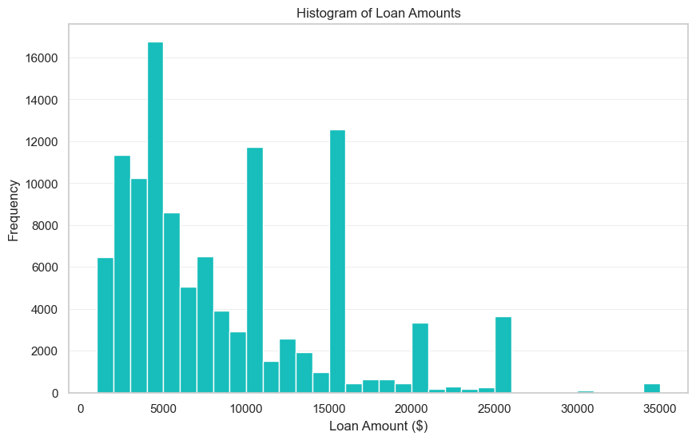

```python
sns.set(style="whitegrid")
plt.figure(figsize=(10, 6))
bins = np.arange(df['LoanAmount'].min(), df['LoanAmount'].max() + 1000, 1000)

ax = sns.histplot(df['LoanAmount'], bins=bins, kde=False, color='#17BEBB', alpha=1)
ax.grid(True, axis='y', color='grey', linestyle='-', linewidth=0.5, alpha=0.2)
ax.xaxis.grid(False)

plt.title('Histogram of Loan Amounts')
plt.xlabel('Loan Amount ($)')
plt.ylabel('Frequency')

plt.show()
```

```python
description = df['LoanAmount'].describe()
mode = df['LoanAmount'].mode()[0]
skew = df['LoanAmount'].skew()
kurt = df['LoanAmount'].kurt()
Borrower_APR_des = pd.DataFrame(description).transpose()

Borrower_APR_des['Mode'] = mode
Borrower_APR_des['Skew'] = skew
Borrower_APR_des['Kurt'] = kurt

Borrower_APR_des.transpose()
```

|  | LoanAmount |
| --- | --- |
| count | 113937.000000 |
| mean | 8337.013850 |
| std | 6245.800580 |
| min | 1000.000000 |
| 25% | 4000.000000 |
| 50% | 6500.000000 |
| 75% | 12000.000000 |
| max | 35000.000000 |
| Mode | 4000.000000 |
| Skew | 1.221169 |
| Kurt | 1.325853 |

**Observation:**

The distribution of **Loan Amounts** is positively skewed, with a mean of `$8,337`, which is higher than the median of `$6,500`, indicating that more loans tend to be on the lower end. The histogram shows a gradual decline in frequency as loan amounts increase, with a noticeable spike in frequency at round numbers, such as `$4,000` and `$10,000`, suggesting a preference for these amounts among borrowers. The highest loan amount recorded is `$35,000`, and the `top 25%` of loans exceed `$12,000`, indicating that a significant portion of borrowers tend to borrow higher amounts. With a skew of 1.22 and kurtosis of 1.33, the data exhibits a slight rightward skew and moderate peakedness.

## Overview of Loan Status Categories

**Question:** How are the loans distributed across different **Loan Status** categories?

> We will analyze the distribution of **Loan Status** using a **Count Plot**.

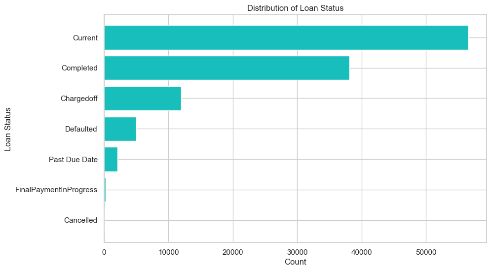

```python
# Creating summarized data table of loan statuses
status_counts = df['Loan_Status'].value_counts()

# Create the horizontal bar chart
plt.figure(figsize=(10, 6))
bars = plt.barh(status_counts.index, status_counts.values, color='#17BEBB')
plt.gca().invert_yaxis()

# Title and labels
plt.title('Distribution of Loan Status')
plt.ylabel('Loan Status')
plt.xlabel('Count')

plt.show()
```

```python
status_counts  =  pd.DataFrame(df['Loan_Status'].value_counts())
status_percentages = pd.DataFrame(df['Loan_Status'].value_counts(normalize=True) * 100)
status_counts.columns = ['Counts']
status_percentages.columns = ['Percentage']
combined_status = pd.concat([status_counts, status_percentages], axis=1)

combined_status
```

|  | Counts | Percentage |
| --- | --- | --- |
| Current | 56576 | 49.655511 |
| Completed | 38074 | 33.416713 |
| Chargedoff | 11992 | 10.525115 |
| Defaulted | 5018 | 4.404188 |
| Past Due Date | 2067 | 1.814160 |
| FinalPaymentInProgress | 205 | 0.179924 |
| Cancelled | 5 | 0.004388 |

**Observation:**

This analysis of loan statuses, visualized in a **count plot**, reveals that nearly half (49.66%) of the loans are currently active and on schedule for payments. A significant portion, 33.42%, represents loans that have been successfully completed. On the other hand, 10.53% of the loans have been charged off, and 4.4% of the records indicate defaults. Additionally, 1.81% of loans are past due, while only 0.18% of loans are in the final payment stage. A minimal 0.004% of loans have been cancelled. These findings suggest a relatively high number of active loans and completed repayments, with a smaller proportion experiencing defaults or delinquencies.

## Distributon of Borrower Rate

**Question:** What does the distribution of Borrower Rate Look Like?

> We will first take a look at the distribution of **Borrower Rate** using a **Histogram**.

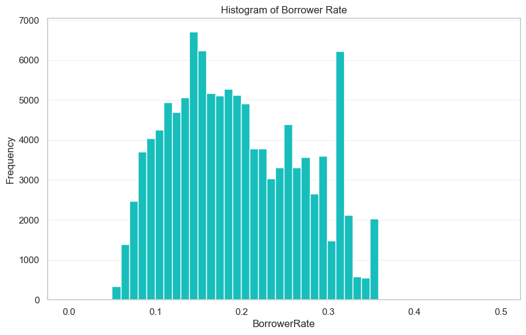

```python
# Creating the Plot
sns.set(style="whitegrid")
plt.figure(figsize=(10, 6))

# Plotting the Data
ax = sns.histplot(df['BorrowerRate'], bins=50, kde=False, color='#17BEBB', alpha=1)

# Plotting Values
ax.grid(True, axis='y', color='grey', linestyle='-', linewidth=0.5, alpha=0.2)
ax.xaxis.grid(False)
plt.title('Histogram of Borrower Rate')
plt.xlabel('BorrowerRate')
plt.ylabel('Frequency')
plt.show()
```

```python
# Discriptive statistics

description = df['BorrowerRate'].describe()
mode = df['BorrowerRate'].mode()[0]
skew = df['BorrowerRate'].skew()
kurt = df['BorrowerRate'].kurt()
Borrower_rate_des = pd.DataFrame(description).transpose()

Borrower_rate_des['Mode'] = mode
Borrower_rate_des['Skew'] = skew
Borrower_rate_des['Kurt'] = kurt

Borrower_rate_des.transpose()
```

|  | BorrowerRate |
| --- | --- |
| count | 113937.000000 |
| mean | 0.192764 |
| std | 0.074818 |
| min | 0.000000 |
| 25% | 0.134000 |
| 50% | 0.184000 |
| 75% | 0.250000 |
| max | 0.497500 |
| Mode | 0.317700 |
| Skew | 0.275994 |
| Kurt | -0.906859 |

**Observation:**

The Borrower Rate data exhibits a positively skewed distribution. The frequency of loans begins to rise significantly from the 5% mark, with a sharp increase up to around 16%, where it peaks. After this peak, the frequency gradually decreases until reaching 36%. A distinct spike in the number of loans occurs around a 32% interest rate, which stands out compared to surrounding values. The mode of the distribution is 31.7%, and the distribution is characterized by a slightly skewed curve, as indicated by a skewness of 0.28. The overall distribution is short-tailed with a positive skew, suggesting that most borrowers are clustered in the lower Borrower Rate range, with a few loans extending into the higher range.

To get another view of the **BorrowerRate**, lets take a look at the data in the form of a **Box Plot**.

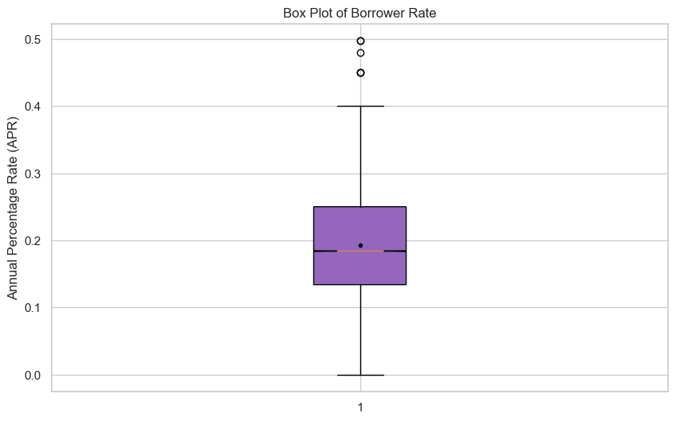

```python
plt.figure(figsize=(10, 6))
bp = plt.boxplot(df['BorrowerRate'].dropna(), notch=True, vert=True, patch_artist=True,
                 showmeans=True, meanprops={'marker':'.', 'markerfacecolor':'black', 'markeredgecolor':'black'})
for box in bp['boxes']:
    box.set_facecolor('#9467bd')
ax.grid(True, axis='y', color='grey', linestyle='-', linewidth=0.2, alpha=0.1)
plt.title('Box Plot of Borrower Rate')
plt.ylabel('Annual Percentage Rate (APR)')
```

```python
Q1 = df['BorrowerRate'].quantile(0.25)
Q3 = df['BorrowerRate'].quantile(0.75)
IQR = Q3 - Q1

outliers = df[(data['BorrowerRate'] < (Q1 - 1.5 * IQR)) | (df['BorrowerRate'] > (Q3 + 1.5 * IQR))]
outliers
```

|  | LoanOriginationDate | LoanStatus | Loan_Status | LoanAmount | Term | MonthlyLoanPayment | StatedMonthlyIncome | IncomeVerifiable | DebtToIncomeRatio | CreditScore | CreditGrade | ClosedDate | BorrowerAPR | add_cost | BorrowerRate | margin | LenderYield | EstimatedEffectiveYield | EstimatedLoss | EstimatedReturn | Investors | ListingCategory | BorrowerState | Occupation | Emp_status | Emp_duration | IsBorrowerHomeowner | CurrentlyInGroup | GroupKey | … |
| --- | --- | --- | --- | --- | --- | --- | --- | --- | --- | --- | --- | --- | --- | --- | --- | --- | --- | --- | --- | --- | --- | --- | --- | --- | --- | --- | --- | --- | --- | --- |
| 18326 | 2006-03-15 | Defaulted | Defaulted | 3000 | 36 | 153.21 | 10000.000000 | True | 0.10252 | NaN | HR | 2007-01-14 | 0.45857 | 0.00857 | 0.4500 | 0.0175 | 0.4325 | NaN | NaN | NaN | 21 | Not Available | NaN | NaN | NaN | NaN | False | False | F555336594467179889CEFB | … |
| 22195 | 2006-03-17 | Chargedoff | Chargedoff | 1789 | 36 | 91.37 | 2916.666667 | True | 0.35430 | NaN | HR | 2009-02-15 | 0.46201 | 0.01201 | 0.4500 | 0.0175 | 0.4325 | NaN | NaN | NaN | 21 | Not Available | NaN | NaN | NaN | NaN | False | False | F555336594467179889CEFB | … |
| 36018 | 2006-02-27 | Completed | Completed | 1500 | 36 | 80.94 | 2838.000000 | True | 0.02852 | NaN | HR | 2006-03-14 | 0.51229 | 0.01479 | 0.4975 | 0.0050 | 0.4925 | NaN | NaN | NaN | 9 | Not Available | NaN | NaN | NaN | NaN | False | False | NaN | … |
| 56761 | 2006-03-21 | Defaulted | Defaulted | 3000 | 36 | 161.88 | 0.000000 | False | 0.03909 | NaN | HR | 2006-09-19 | 0.50633 | 0.00883 | 0.4975 | 0.0175 | 0.4800 | NaN | NaN | NaN | 21 | Not Available | NaN | NaN | NaN | NaN | False | False | F555336594467179889CEFB | … |
| 82043 | 2006-03-07 | Defaulted | Defaulted | 3000 | 36 | 158.66 | 1583.333333 | True | 0.10021 | NaN | HR | 2006-09-05 | 0.48873 | 0.00873 | 0.4800 | 0.0050 | 0.4750 | NaN | NaN | NaN | 20 | Not Available | NaN | NaN | NaN | NaN | False | False | NaN | … |
| 103973 | 2006-03-09 | Defaulted | Defaulted | 2800 | 36 | 143.00 | 3750.000000 | True | 0.19413 | NaN | HR | 2006-10-08 | 0.45857 | 0.00857 | 0.4500 | 0.0175 | 0.4325 | NaN | NaN | NaN | 22 | Not Available | NaN | NaN | NaN | NaN | False | False | F555336594467179889CEFB | … |

**Observation:**

The Box Plot provides a valuable perspective by emphasizing the five-number summary, along with other central tendencies and measures of spread for the Borrower Rate. Notably, a few outliers exceed the upper boundary defined by the maximum calculated whisker. These outliers highlight exceptional cases outside the typical range of Borrower Rates.

Additionally, the plot reveals that the mean Borrower Rate is higher than the median, confirming that the data is positively skewed. This skewness is consistent with the presence of a longer tail on the right side of the distribution, even though only a small proportion of the data consists of outliers. Such a distribution suggests that, while Borrower Rates are generally concentrated around lower and middle values, there are significant instances of higher rates.

From the box plot and the overall distribution analysis, it becomes clear that a substantial number of loans are concentrated around a 32% Borrower Rate. This specific rate appears to be a modal value, indicating a common rate that borrowers receive.

### Discuss the distribution(s) of your variable(s) of interest. Were there any unusual points? Did you need to perform any transformations?

> For my analysis, I decided to take a look at the distribution of **`LoanAmount`** using a **`Histogram`**. We observe a positively skewed distribution for **`LoanAmount`**, with the mean higher than the median. The decrease in frequency as we move to higher loan amounts is gradual; however, there is a spike in frequency at round figures, indicating that people tend to prefer loans in round amounts. The maximum loan borrowed is `$35,000`, while the top 25% in loan amounts are above `$12,000`.

> For my analysis of **`LoanStatus`**, I used a **`Horizontal Bar Plot`**. The visualization of **`LoanStatus`** shows that nearly half (49.66%) of the loans are currently active and are on schedule for payments. On the other hand, 4.4% of our records show defaulters, and 1.8% indicate significant delinquencies. Completed and charged-off loans are the ones that have been closed. 33.4% of the loans have been completed on schedule, while 10.5% have been charged off.

### Of the features you investigated, were there any unusual distributions? Did you perform any operations on the data to tidy, adjust, or change the form of the data? If so, why did you do this?

# Bivariate Exploration

## 1) Analyzing 'LoanStatus' (Completed and Charged Off) by Categorical Features.

**Question:** How do different categorical variables compare in terms of closed loan statuses?

> **100% Stacked Bar chart** segmented by the outcomes of **Completed** and **Chargedoff** loans for each categorical variable.

```python
#Creating a separate Dataframe
statuses = ['Completed', 'Chargedoff']
df1 = df[df['LoanStatus'].isin(statuses)]
```

```python
# Define the order for the 'CreditGrade' categories
grade_order = ['AA', 'A', 'B', 'C', 'D', 'E', 'HR']

# Ensure the 'CreditGrade' column is using the correct DataFrame and set the order
df1['CreditGrade'] = pd.Categorical(df1['CreditGrade'], categories=grade_order, ordered=True)
df1['ProsperRating (Alpha)'] = pd.Categorical(df1['CreditGrade'], categories=grade_order, ordered=True)
```

```python
# Listing all categorical variables
categorical_columns = df1.select_dtypes(include=['object', 'category']).columns.tolist()
possible_categorical_integers = [col for col in df1.select_dtypes(include=['int', 'int64']).columns if df1[col].nunique() < 20]
all_categorical = list(set(categorical_columns + possible_categorical_integers))

# Removing date columns and columns with too many unique values
date_columns = ['LoanOriginationDate', 'ClosedDate', 'ListingCreationDate', 'LoanOriginationQuarter', 'LoanKey','GroupKey']
all_categorical = [col for col in all_categorical if col not in date_columns]
#all_categorical
```

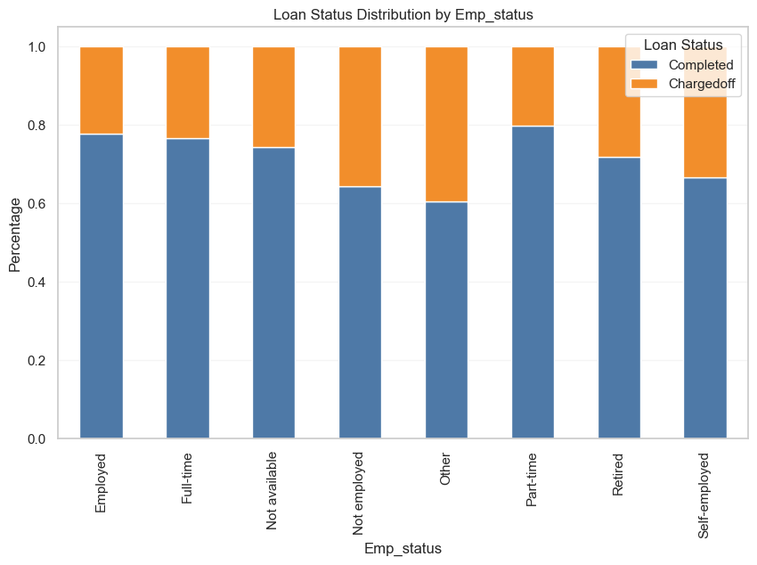

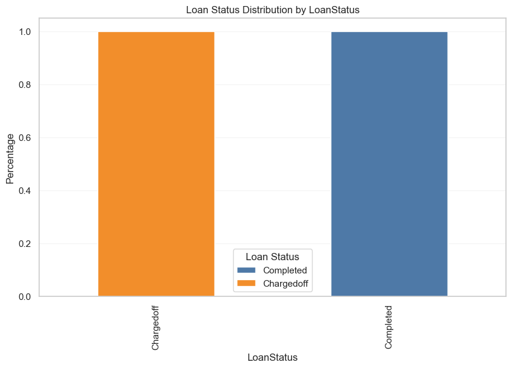

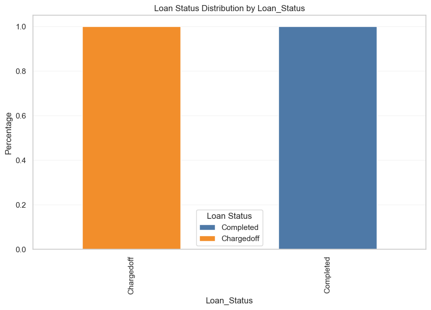

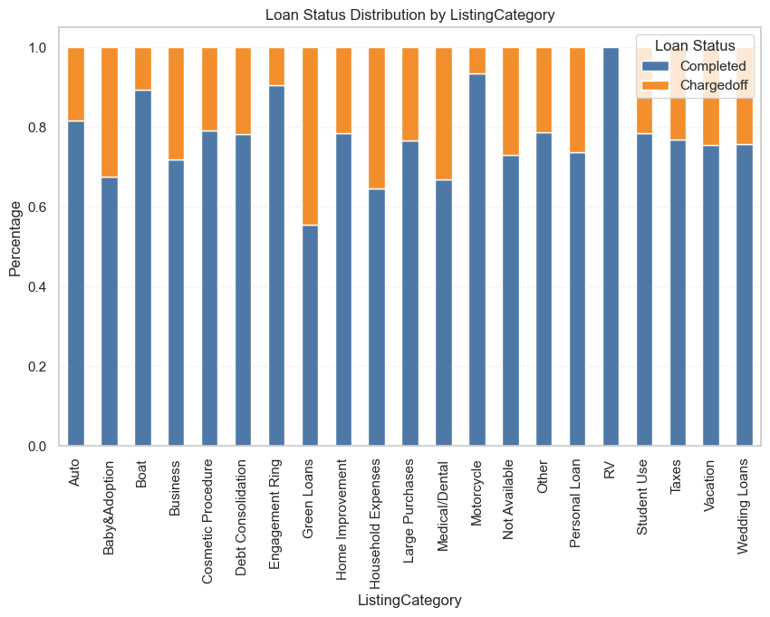

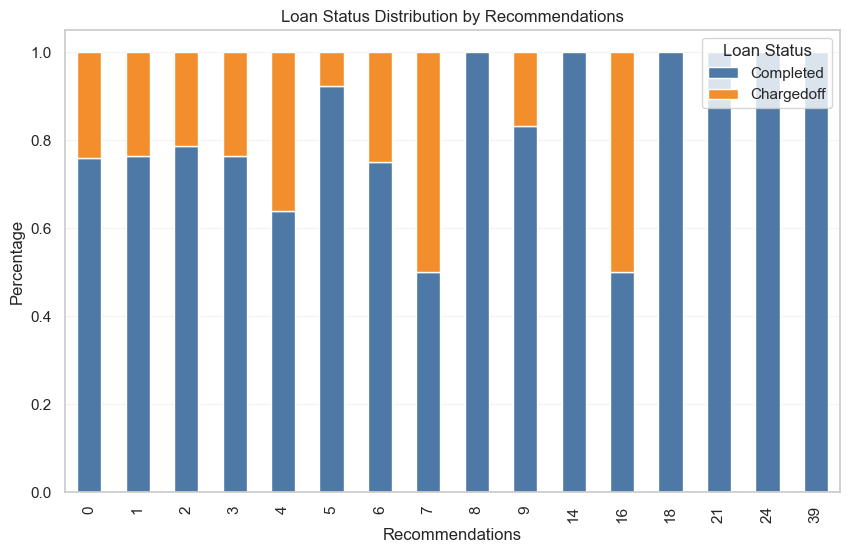

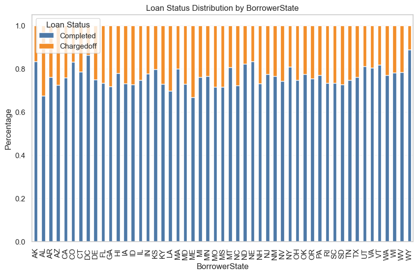

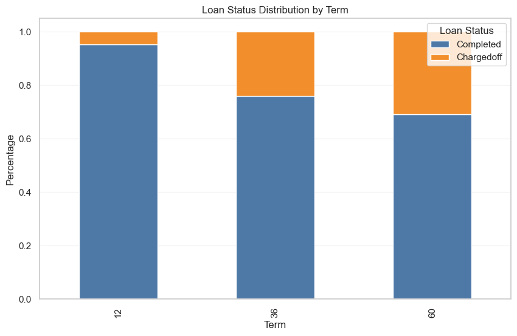

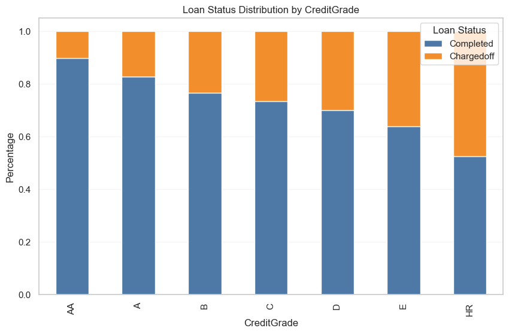

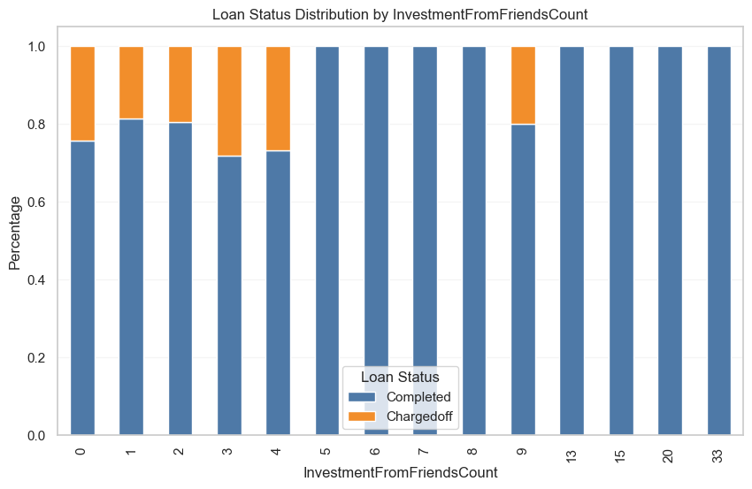

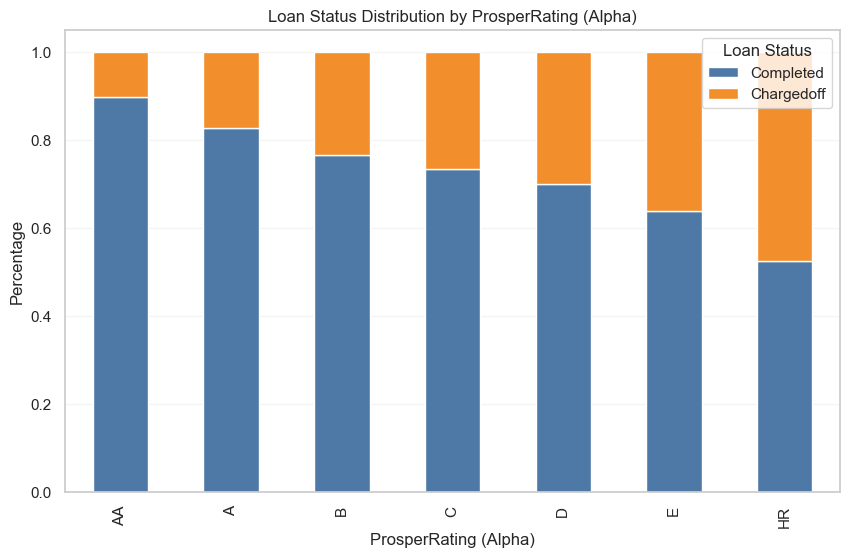

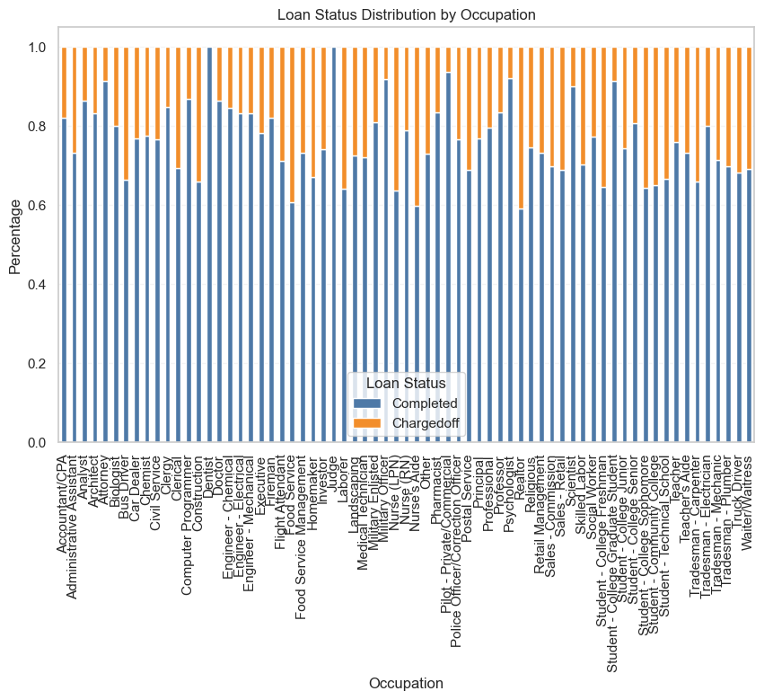

```python
def prepare_data_for_stacked_chart(df, category):
    # Create a crosstab and normalize by index
    crosstab = pd.crosstab(df[category], df['LoanStatus'], normalize='index')
    # Specify the desired order of the categories
    desired_order = ['Completed','Chargedoff']
    # Filter the columns based on the desired order and existing columns in crosstab
    columns = [col for col in desired_order if col in crosstab.columns]
    # Reorder the columns according to the desired order
    if columns:
        crosstab = crosstab[columns]
    return crosstab

def plot_stacked_chart(data, title, xlabel):
    colors = ['#4E79A7','#F28E2B' ]
    # Plot the data
    data.plot(kind='bar', stacked=True, figsize=(10, 6), color=colors)
    plt.title(title)
    plt.xlabel(xlabel)
    plt.ylabel('Percentage')
    plt.grid(True, linewidth=1, alpha=0.2)
    plt.gca().xaxis.grid(False)
    plt.legend(title='Loan Status')

    plt.show()

for var in all_categorical:
    if var in df1.columns:
        data = prepare_data_for_stacked_chart(df1, var)
        plot_stacked_chart(data, f'Loan Status Distribution by {var}', var)
    else:
        print(f"{var} is not in the DataFrame columns.")
```

In the above **100% Bar Charts**, we explore some interesting relationships between the final status of loans and various categorical variables.

## Visualizing Correlations Among Numeric Variables with a Heat Map

**Question:** How do various numeric variables correlate?

> **Heatmap** to depict correlation between Numeric Variables.

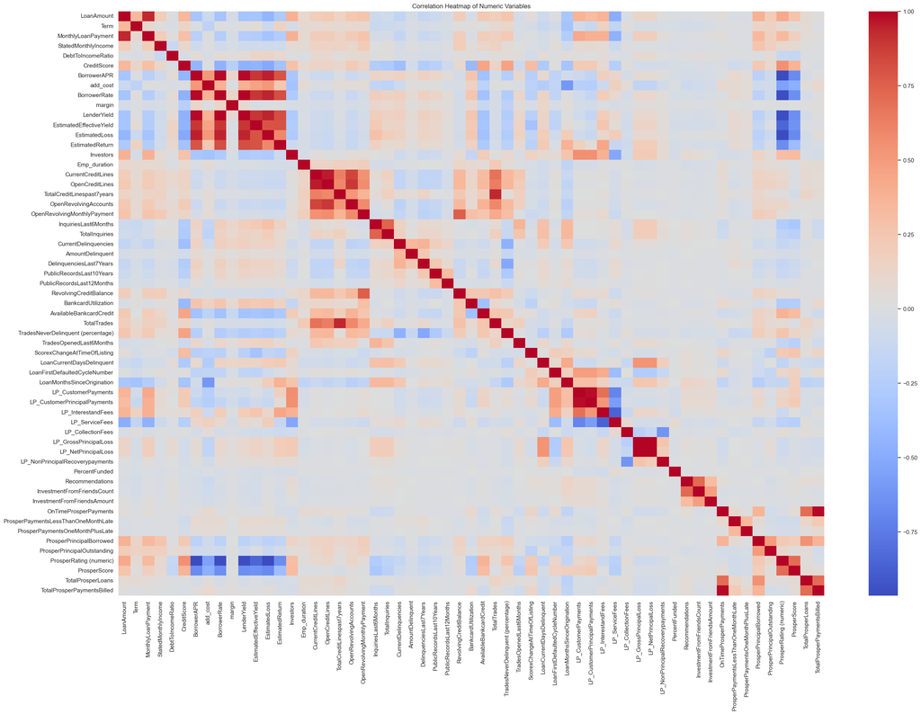

```python
    numeric_columns = df.select_dtypes(include=['number']).columns.tolist()
    # Calculate correlation matrix
    corr_matrix = df[numeric_columns].corr()

    # Plot the heatmap
    plt.figure(figsize=(30, 20))
    sns.heatmap(corr_matrix, annot=False, fmt=".2f", cmap='coolwarm', cbar=True)
    plt.title('Correlation Heatmap of Numeric Variables')
    plt.show()
```

```python
# Finding strong correlation between columns
strong_corr_dict = {}

for col in corr_matrix.columns:
    strong_indices = corr_matrix.index[(corr_matrix[col].abs() >= 0.30) & (corr_matrix.columns != col)]
    if not strong_indices.empty:
        strong_corr_dict[col] = {index: corr_matrix.at[index, col] for index in strong_indices}
```

```python
# Highlighting our points of intrest
imp_vars = ['LoanAmount', 'CreditScore', 'BorrowerRate', 'ProsperRating (numeric)', 'ProsperScore',  'EstimatedLoss', 'EstimatedReturn']

for column in imp_vars:
    print(column + ":")
    for key, value in strong_corr_dict[column].items():
        print(f"  {key}: {value}")
    print()
```

```
LoanAmount:
  Term: 0.3389274577342384
  MonthlyLoanPayment: 0.9319836797293888
  CreditScore: 0.3408744514784254
  BorrowerAPR: -0.32288668996967973
  BorrowerRate: -0.32895994993853817
  LenderYield: -0.3284551073492897
  EstimatedEffectiveYield: -0.32726571347949557
  EstimatedLoss: -0.4298904027412948
  Investors: 0.38009264656367703
  LoanMonthsSinceOrigination: -0.30905756538737433
  LP_CustomerPayments: 0.3648306028911062
  LP_CustomerPrincipalPayments: 0.32296516648064244
  LP_InterestandFees: 0.3663585451687578
  LP_ServiceFees: -0.4833669851311357
  ProsperPrincipalBorrowed: 0.3822678384140568
  ProsperRating (numeric): 0.4285572220316174

CreditScore:
  LoanAmount: 0.3408744514784254
  BorrowerAPR: -0.42970732205875595
  BorrowerRate: -0.4615666774285485
  LenderYield: -0.45435002294714455
  EstimatedEffectiveYield: -0.44512663375359574
  EstimatedLoss: -0.5112628168679326
  EstimatedReturn: -0.3462327315580701
  CurrentDelinquencies: -0.3684500462107783
  BankcardUtilization: -0.40533804683991187
  AvailableBankcardCredit: 0.4532569311343188
  TradesNeverDelinquent (percentage): 0.4688990018456166
  ScorexChangeAtTimeOfListing: 0.3171795975784951
  LoanMonthsSinceOrigination: -0.33289399490383087
  ProsperRating (numeric): 0.5488738499270548
  ProsperScore: 0.3696030474032723

BorrowerRate:
  LoanAmount: -0.32895994993853817
  CreditScore: -0.4615666774285485
  BorrowerAPR: 0.9898239703033347
  add_cost: 0.38273862542142106
```

[output cut: 46 more lines]

```
  AvailableBankcardCredit: -0.3427707434475397
  ProsperRating (numeric): -0.9641819094002914
  ProsperScore: -0.6737269899619254

EstimatedReturn:
  CreditScore: -0.3462327315580701
  BorrowerAPR: 0.7942751982948073
  BorrowerRate: 0.817669869185915
  LenderYield: 0.8176540710496515
  EstimatedEffectiveYield: 0.8015679050969727
  EstimatedLoss: 0.5910556660529057
  LoanMonthsSinceOrigination: 0.37272723731150287
  LP_InterestandFees: 0.44042467118923234
  ProsperRating (numeric): -0.6599802455670876
  ProsperScore: -0.38321059157505266
```

### Observations

In the above Heat Map, we see multiple features that have significant correlations with our features of interest. We observe a mix of both subtle and strong correlations. These correlations are crucial for making predictions, which helps us in the planning process to optimize our products.

#### `Loan Amount`

- **`Loan Amount`** has a weak positive relationship with **`Term`**. This is probably because larger loans could take longer to pay and hence are taken for longer durations.
- We can see that **`Loan Amount`** has a significant correlation of `0.34` with **`Credit Score`**. This could be because higher loans are more likely to be given to borrowers with good credit scores. We can examine this further in **`multivariate analysis`**.
- It also has a negative relationship of `-0.32` with **`Borrower Rate`**. This is possibly because higher **`Loan Amounts`** are generally given to people with stronger credit scores, and considering this, lenders are willing to lend at lower interest rates due to lower risks. We can analyze this in **`multivariate analysis`** to verify this.
- **`Loan Amount`** also has a notable negative relationship of `-0.43` with **`Estimated Loss`**.
- With a larger number of **`Investors`**, we also see a larger **`Loan Amount`**. The two have a positive correlation of `0.38`.
- **`Loan Amount`** has a significant positive relationship of `0.43` with **`Prosper Rating`**.

## Visualizing Loan Amount Distribution by Credit Grade Using a Box Plot

**Question:** How is the distribution of loan amounts across different credit grades?

> A box plot will be used to depict the distribution of loan amounts across various credit grades.

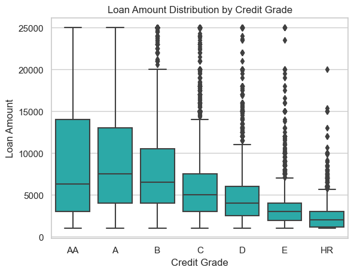

```python
# Define the order for the Credit Grades
grade_order = ['AA', 'A', 'B', 'C', 'D', 'E', 'HR']

# Setting order to the column
df['CreditGrade'] = pd.Categorical(df['CreditGrade'], categories=grade_order, ordered=True)

# Create a boxplot to visualize the 'LoanAmount' distribution by 'CreditGrade' with custom color
sns.boxplot(x='CreditGrade', y='LoanAmount', data=df, color="#17BEBB")
plt.title('Loan Amount Distribution by Credit Grade')
plt.xlabel('Credit Grade')
plt.ylabel('Loan Amount')
plt.show()
```

```python
# Group by CreditGrade and calculate summary statistics for LoanAmount
summary_stats = df.groupby('CreditGrade')['LoanAmount'].describe()

# Display the summary statistics table
print(summary_stats)
```

```
              count         mean          std     min     25%     50%  \
CreditGrade
AA           3509.0  9144.065831  7500.879864  1000.0  3000.0  6323.0
A            3315.0  9292.163801  7001.416936  1000.0  4000.0  7500.0
B            4389.0  8313.081340  5900.595373  1000.0  4000.0  6500.0
C            5649.0  6100.663480  4601.704519  1000.0  3000.0  5000.0
D            5153.0  4785.527460  3658.022660  1000.0  2500.0  4000.0
E            3289.0  3391.941320  2635.387025  1000.0  1990.0  3000.0
HR           3508.0  2453.612885  1619.211952  1000.0  1200.0  2000.0

                 75%      max
CreditGrade
AA           14000.0  25000.0
A            13000.0  25000.0
B            10500.0  25000.0
C             7500.0  25000.0
D             6000.0  25000.0
E             4000.0  25000.0
HR            3000.0  20000.0
```

## Talk about some of the relationships you observed in this part of the investigation. How did the feature(s) of interest vary with other features in the dataset?

In the univariate analysis, we studied the distribution of variables like `Loan Status`, `Borrower Rate`, and `Loan Amounts`. In this bivariate analysis, we check their correlations with other variables.

### `Loan Status`

In the above 100% bar charts, we explore some interesting relationships between the final status of loans and various categorical variables.

### `Loan Amount`

- **`Loan Amount`** has a weak positive relationship with **`Term`**—larger loans tend to have longer terms.
- There is a significant correlation of **0.34** between **`Loan Amount`** and **`Credit Score`**, indicating that higher loans are generally given to borrowers with better credit scores.
- A negative correlation of **-0.32** with **`Borrower Rate`** suggests that larger loans are offered at lower interest rates.
- **`Loan Amount`** shows a notable negative correlation of **-0.43** with **`Estimated Loss`**.
- A positive correlation of **0.38** exists between **`Loan Amount`** and the number of **`Investors`**.

## Did you observe any interesting relationships between the other features (not the main feature(s) of interest)?

> Yes. Credit Score is an independent variable from the context of our analysis. However, we can see how it correlates with other variables on the dataset.

## 1) Visualising Correlations between Loan Amount, Credit Score and Borrower Rate.

**Question:** How do Loan Amount and Credit Score interact, and how is this relationship influenced by Borrower Rate?

> **Scatter Plot** displaying the relationship between **Loan Amount**, **Credit Score**, **Borrower Rate**

```python
# Creating Dataset
df2 = df[['LoanAmount', 'BorrowerRate', 'CreditScore', 'CreditGrade']]

#Ensuring correct Datatypes
df2['LoanAmount'] = df2['LoanAmount'].astype('float64')
df2['BorrowerRate'] = df2['BorrowerRate'].astype('float64')
df2['CreditScore'] = df2['CreditScore'].astype('float64')
df2['CreditGrade'] = df['CreditGrade'].astype('category')

#Removing Null Values
df2.dropna(subset = ['LoanAmount', 'BorrowerRate', 'CreditScore', 'CreditGrade'], inplace=True)
```

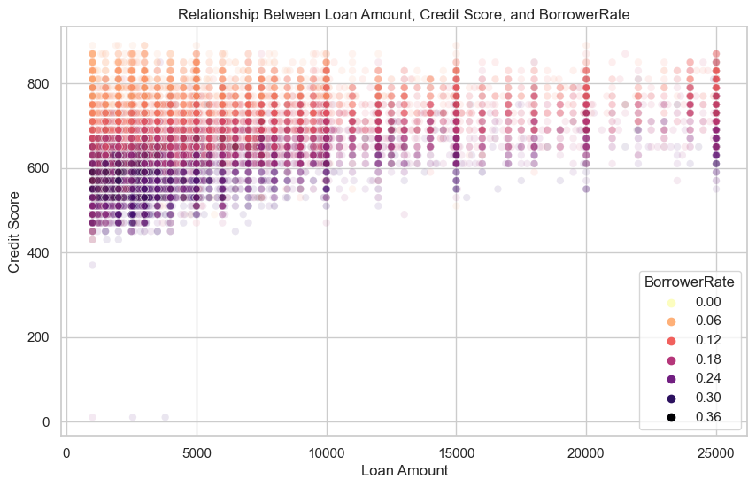

```python
plt.figure(figsize=(10, 6))

# Creating a Scatterplot
sns.scatterplot(
    x=df2['LoanAmount'],
    y=df2['CreditScore'],
    hue=df2['BorrowerRate'],
    palette='magma_r',
    alpha=0.1
)

# Creating a Title and Label
plt.title('Relationship Between Loan Amount, Credit Score, and BorrowerRate')
plt.xlabel('Loan Amount')
plt.ylabel('Credit Score')
plt.grid(True)
plt.show()
```

## 2) Visualizing Correlations between Loan Amount, Borrower Rate, and Credit Score segmented by Credit Grade

**Question:** How do Loan Amount and Credit Score interact with Borrower Rate for each Credit Grade?

> **Scatter Plot**: Displays the relationship between **Loan Amount**, **Credit Score**, and **Borrower Rate**, segmented by **Credit Grade**. Each plot highlights variations in borrower rates across different credit grades.

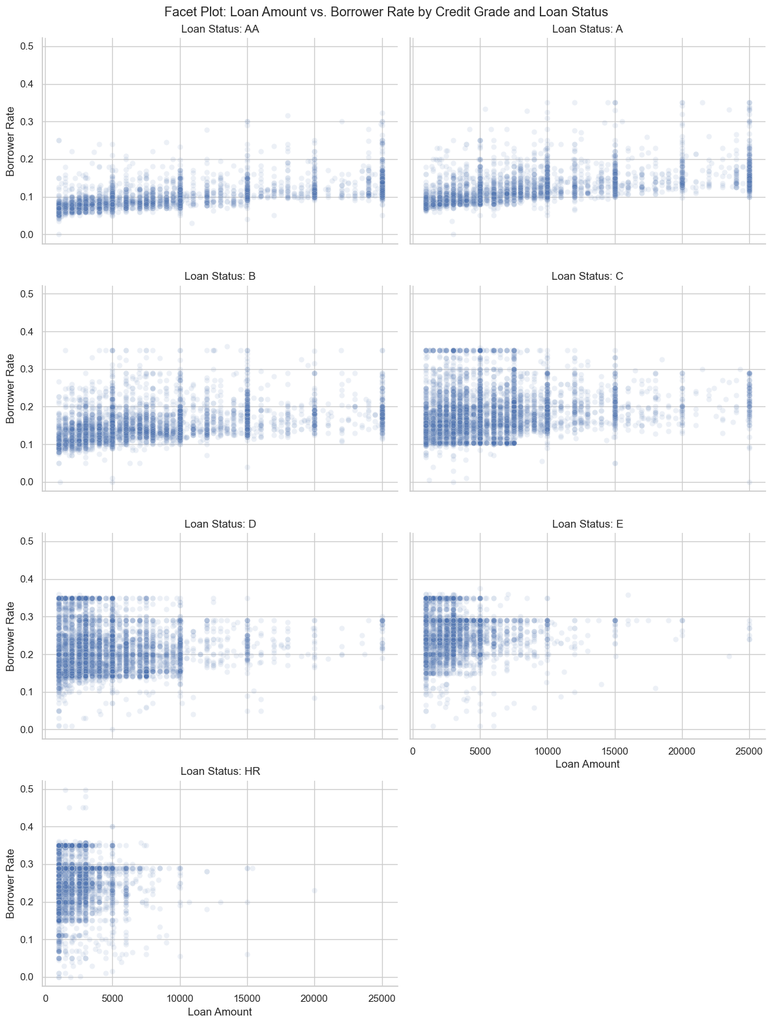

```python
# Drop rows with missing values in the relevant columns
plot_data = df[['LoanAmount', 'Term', 'Loan_Status', 'CreditGrade', 'BorrowerRate']].dropna()
plot_data['Term'] = pd.Categorical(plot_data['Term'])

# Define a custom color palette for Loan_Status
#custom_palette = {"Completed": "#4E79A7", "Chargedoff": "#F28E2B"}

# Create the facet grid
g = sns.FacetGrid(
    plot_data,
    col="CreditGrade",
    col_wrap = 2,
    #hue="Loan_Status",
    #palette=custom_palette,
    height=4,
    aspect=1.5
)

# Map the data onto the grid using scatterplot
g.map(sns.scatterplot, "LoanAmount", "BorrowerRate", alpha=0.1)

# Add legend and titles
g.set_axis_labels("Loan Amount", "Borrower Rate")
g.set_titles(row_template="{row_name}", col_template="Loan Status: {col_name}")
g.fig.suptitle("Facet Plot: Loan Amount vs. Borrower Rate by Credit Grade and Loan Status")

# Adjust the layout to prevent overlap
g.fig.subplots_adjust(top=0.95)
plt.show()
```

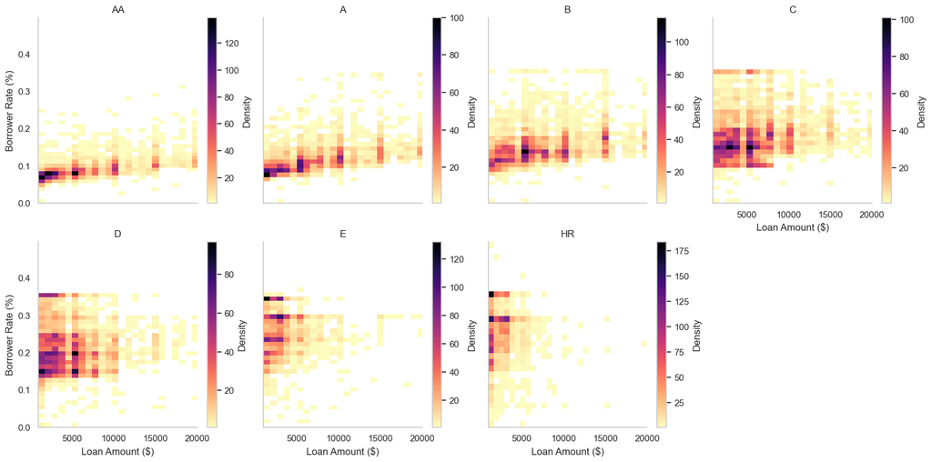

```python
# Define a custom function to use Matplotlib's hist2d
def hist2d_plot(x, y, **kwargs):
    cbar_label = kwargs.pop("cbar_label", "Density")
    h = plt.hist2d(x, y, bins=30, cmap="magma_r", cmin=1)
    if "cbar" not in plt.gcf().texts:
        cbar = plt.colorbar(h[3], ax=plt.gca())
        cbar.set_label(cbar_label)

# Creating a fasceted grid
g = sns.FacetGrid(data=df1, col="CreditGrade", col_wrap=4, height=4)

# Pass the custom plot function to FacetGrid
g.map(hist2d_plot, "LoanAmount", "BorrowerRate", cbar_label="Density")

# Set axis labels
g.set_axis_labels("Loan Amount ($)", "Borrower Rate (%)")
g.set_titles("{col_name}")

plt.show()
```

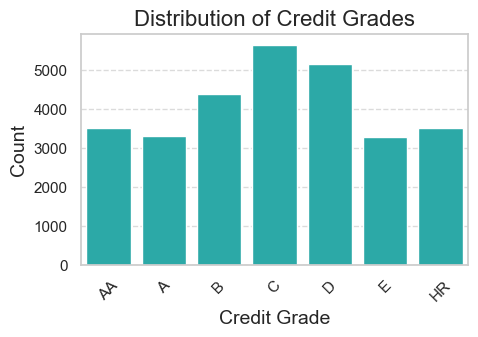

```python
# Create a Count Plot
plt.figure(figsize=(5, 3))
sns.countplot(x='CreditGrade', data=df, color = "#17BEBB")

# Add Title and Labels
plt.title('Distribution of Credit Grades', fontsize=16)
plt.xlabel('Credit Grade', fontsize=14)
plt.ylabel('Count', fontsize=14)
plt.xticks(rotation=45)  # Rotate x-axis labels if necessary
plt.grid(axis='y', linestyle='--', alpha=0.7)

# Show the Plot
plt.show()
```

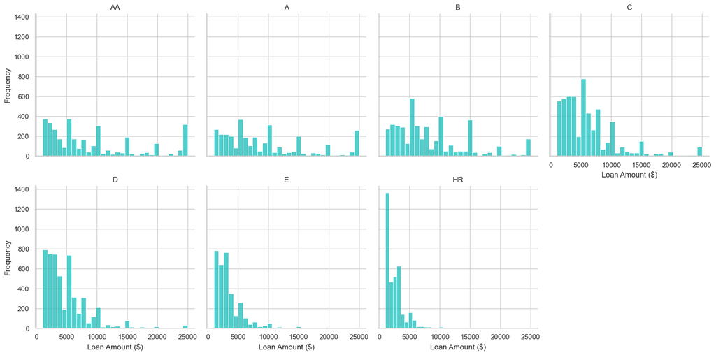

```python
#Creating the facet grid
g = sns.FacetGrid(data=df, col="CreditGrade", col_wrap=4, height=4)

# Map the 1D histogram plot function onto the grid
g.map(sns.histplot, "LoanAmount", kde=False, bins=30, color="#17BEBB")  # Customize bins and color

# Set axis labels
g.set_axis_labels("Loan Amount ($)", "Frequency")
g.set_titles("{col_name}")

plt.show()
```

## 3) Visualizing Loan Amount vs. Borrower Rate by Credit Grade and Loan Status

**Question:** How do Loan Amount and Borrower Rate vary across different Credit Grades and Loan Statuses?

> **Faceted Scatter Plot**: Displays the relationship between **Loan Amount** and **Borrower Rate**, segmented by **Credit Grade** (faceted columns).
> - Points are color-coded by **Loan Status** Blue symbolises "Completed" while Orange symbolises "Chargedoff" loans.

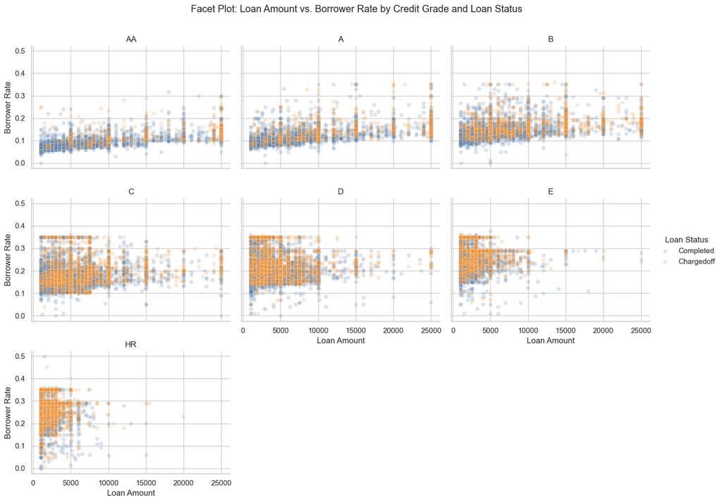

```python
# Drop rows with missing values in the relevant columns
plot_data = df1[['LoanAmount', 'Term', 'Loan_Status', 'CreditGrade', 'BorrowerRate']].dropna()
plot_data['Term'] = pd.Categorical(plot_data['Term'])

# Define a custom color palette for Loan_Status
custom_palette = {
    "Completed": "#4E79A7",
    "Chargedoff": "#F28E2B"
}

# Create the facet grid
g = sns.FacetGrid(
    plot_data,
    col="CreditGrade",
    col_wrap=3,
    hue="Loan_Status",
    palette=custom_palette,
    height=3.5,
    aspect=1.3
)

# Map the data onto the grid using scatterplot
g.map(sns.scatterplot, "LoanAmount", "BorrowerRate", alpha=0.2)

# Add legend and titles
g.set_axis_labels("Loan Amount", "Borrower Rate")
g.set_titles(row_template="{row_name}", col_template="{col_name}")
g.fig.suptitle("Facet Plot: Loan Amount vs. Borrower Rate by Credit Grade and Loan Status")

# Add the legend
g.add_legend(title="Loan Status")

# Adjust the layout to prevent overlap
g.fig.subplots_adjust(top=0.9)
plt.show()
```

### Multivariate Plots:

**Plot 1:** Scatter Plot

- **Loan Amount** (x-axis)
- **Credit Score** (y-axis)
- **Borrower Rate** (hue)

**Plot 2:** Faceted Scatter plot

**Plot 3:** Fasceted Heatmap

**Plot 4:** Faceted Scatter Plot

**Plot 5:** Faceted Histogram

- Faceted by: **Credit Grade** (columns)
- **Loan Amount** (x-axis)
- **Frequency** (y-axis)
- Bins: 30

### Observations:

#### 1. **Overall Relationship**

- **Loan Amount and Credit Score**: There is a generally **positive relationship** between these two variables, indicating that borrowers with higher loan amounts tend to have better credit scores.
- **Borrower Rate**: Appears to be **negatively correlated** with both Loan Amount and Credit Score overall. This suggests that borrowers with higher loan amounts or better credit scores are likely to secure **lower interest rates**.

#### 2. **Segmented by Credit Grade**

- When data is segmented by **Credit Grade**, the relationships between these variables show distinct patterns:
  - **Higher Grades (AA, A, B)**: Exhibit a **positive relationship** between Loan Amount and Borrower Rate, potentially reflecting specific borrowing dynamics for individuals with higher credit grades.
  - **Lower Grades (C, D, E, HR)**: Concentrated in the **low loan amount, high borrower rate** regions, creating an **overall negative correlation** across all grades combined.
- This highlights how lower credit grades skew the aggregate data due to their disproportionate influence.

#### 3. **Loan Status Analysis**

- By including **Loan Status** ("Completed" and "Chargedoff") in the analysis, we gain additional insights:
  - **Higher Credit Grades (AA, A, B)**: Show a **lower proportion of Chargedoff loans**, indicating lower credit risk.
  - **Lower Credit Grades (C, D, E, HR)**: Show a **higher proportion of Chargedoff loans**, reflecting greater credit risk.

#### 4. **Implications**

- These observations suggest that **credit grades** strongly influence borrowing dynamics, loan approval trends, and default risks.
- For lower credit grades, borrowers are more likely to experience **higher interest rates** and a **greater risk of loan default**.

# Conclusions

The analysis reveals that creditworthiness plays an important role in determining loan amounts, interest rates, and repayment outcomes. Borrowers with better credit profiles enjoy larger loans, lower rates, and higher completion rates, while lower grades experience higher rates, smaller loans, and increased default risks. These insights underscore the importance of risk assessment and loan structuring in managing loan portfolios effectively. Here is a deeper summary of our findings:

## Summary Findings

### Loan Amount Distribution

- Loan amounts are **positively skewed**, with higher frequencies at round figures, indicating borrower preferences for round-number loans.
- Larger loans tend to be associated with **better credit scores** and **lower borrower rates**.

### Loan Status Trends

- Nearly **50%** of loans are active, while **33.4%** have been successfully completed.
- Charged-off loans account for **10.5%**, with clear correlations to **lower credit grades**, **longer loan terms**, and **higher borrower rates**.
- **Employment status**, **borrower state**, and **occupation** influence loan outcomes significantly.

### Credit Grade Insights

- Higher credit grades (e.g., **AA, A, B**) are associated with **lower interest rates**, **larger loans**, and **fewer defaults**.
- Lower credit grades (e.g., **C, D, E, HR**) face **higher interest rates**, **smaller loan amounts**, and a **greater likelihood of default**.

### Key Bivariate and Multivariate Relationships

- A **positive relationship** exists between **Loan Amount** and **Credit Score**, while **Borrower Rate** shows a **negative correlation** with both.
- Longer loan terms are associated with an **increased likelihood of defaults**.
- Segmented data highlights distinct patterns: **higher grades benefit from favorable borrowing dynamics**, while **lower grades experience financial constraints**.